# Avocado Price Analysis

```python
import pandas as pd
import matplotlib.pyplot as plt
import seaborn as sns
import numpy as np
from scipy import stats
from scipy.stats import linregress
```

```python
data = pd.read_csv('avocado.csv',delimiter = ',')
data.drop(columns='Unnamed: 0',inplace=True)
```

```python
data.info()
```

```
<class 'pandas.core.frame.DataFrame'>
RangeIndex: 18249 entries, 0 to 18248
Data columns (total 13 columns):
 #   Column        Non-Null Count  Dtype
---  ------        --------------  -----
 0   Date          18249 non-null  object
 1   AveragePrice  18249 non-null  float64
 2   Total Volume  18249 non-null  float64
 3   4046          18249 non-null  float64
 4   4225          18249 non-null  float64
 5   4770          18249 non-null  float64
 6   Total Bags    18249 non-null  float64
 7   Small Bags    18249 non-null  float64
 8   Large Bags    18249 non-null  float64
 9   XLarge Bags   18249 non-null  float64
 10  type          18249 non-null  object
 11  year          18249 non-null  int64
 12  region        18249 non-null  object
dtypes: float64(9), int64(1), object(3)
memory usage: 1.8+ MB
```

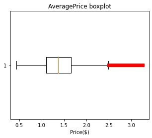

```python
fig,ax = plt.subplots(figsize=(5,4))
plt.boxplot(data['AveragePrice'], 0, 'rs', 0)
plt.title('AveragePrice boxplot')
plt.xlabel('Price($)')
plt.plot()
plt.show()
```

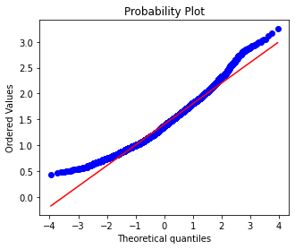

```python
#plot taken from kaggle user, i found it intersting to try and confirm the ditribution this way.
fig,ax = plt.subplots(figsize=(5,4))
ax4 = plt.subplot()
res = stats.probplot(data['AveragePrice'],dist ='norm',plot=plt)
```

As you can see its not a great fit for a normal distriibution.

```
[]
```

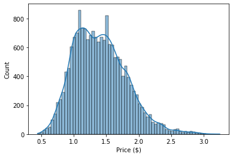

```python
sns.histplot(data['AveragePrice'],kde=True)
plt.xlabel('Price ($)')
plt.plot()
```

It appears to be a bimodal distribution, which is strange for a price of the same item you would expect it to be unimodal.

later in the analysis, I come to compare the variable 'type' which categorizes the avocados between organic and conventional. this explains the bimodal distribution, as the skews for organic and conv are different

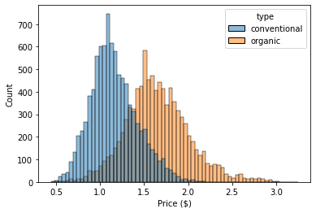

```python
sns.histplot(data,x='AveragePrice',hue='type')
plt.xlabel('Price ($)')
plt.show()
```

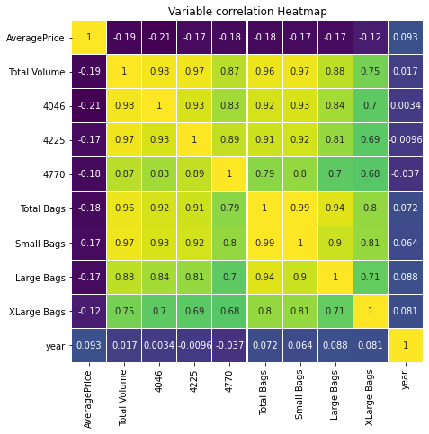

```python
d_corr = data.corr()
fig,ax = plt.subplots(figsize=(7,7))
ax = sns.heatmap(d_corr,annot=True,linewidth=0.01,cbar=False,cmap='viridis')
ax.set_title('Variable correlation Heatmap')
plt.show()
```

## Categorical

### Type organic / conventional

```
[]
```

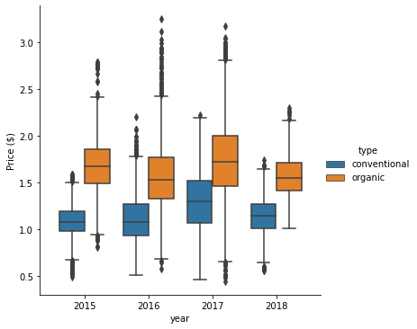

```python
sns.catplot(x ='year',y='AveragePrice', data=data,hue='type',kind='box')
plt.ylabel('Price ($)')
plt.plot()
```

- Organic avocados tend to be more expensive that conventional avocados.

```
[]
```

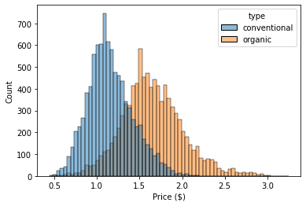

```python
sns.histplot(data,x='AveragePrice',hue='type')
plt.xlabel('Price ($)')
plt.plot()
```

distribution fit

```
[]
```

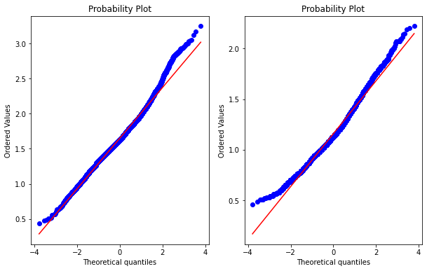

```python
f, ax = plt.subplots(1,2,figsize=(10,6))

stats.probplot(data.loc[data['type']=='organic','AveragePrice'],dist ='norm',plot=ax[0])
stats.probplot(data.loc[data['type']=='conventional','AveragePrice'],dist ='norm',plot=ax[1])
plt.plot()
```

the spread of values for organic is much larger. 4Q >3.0 compared to 4Q<3.0

```python
avo_type  = data.groupby('type').agg(['mean','std','count'])
avo_type = round(avo_type,2)
#mean diff
mean_diff = avo_type['AveragePrice']['mean']['organic']-avo_type['AveragePrice']['mean']['conventional']
#standard deviation
organic_s1 = avo_type['AveragePrice']['std']['organic']
conventional_s2 = avo_type['AveragePrice']['std']['conventional']
print('mean difference',mean_diff,'p')
```

```
mean difference 0.49 p
```

$X_1 =$ Organic Avocados, AveragePrice dist.

$X_2=$ Conventional Avocados, AveragePrice dist.

$\bar{X_1}-\bar{X_2} =$ 0.49

$\alpha = 0.01$

\begin{align*} \sigma^2_{\bar{X_1}+\bar{X_2}}\approx \frac{S_1}{n_1}+\frac{S_2}{n_2}\\ \end{align*}

```python
sampling_stderr = (organic_s1/avo_type['AveragePrice']['count']['organic'])+(conventional_s2/avo_type['AveragePrice']['count']['conventional'])
sampling_stderr = np.sqrt(sampling_stderr)
print('sampling std error approx',sampling_stderr)

crit_limit =2.33
limit = crit_limit*sampling_stderr
print(round(mean_diff - limit,2),'to',round(mean_diff +limit,2))
```

```
sampling std error approx 0.008243223411136655
0.47 to 0.51
```

## Region

Groupby region, with lambda agg to reduce oulier prices.

```python
region_data = data.groupby(['region','type'])['AveragePrice'].agg(['mean',
                                                            lambda x : np.quantile(x,.15),
                                                            lambda x : np.quantile(x,.85)])
region_data = region_data.unstack()
region_data.rename(columns={'<lambda_0>':'q15','<lambda_1>':'q85'},inplace=True)
err_pdata = region_data.copy()
region_data.head()
```

| type region | mean conventional | mean organic | q15 conventional | q15 organic | q85 conventional | q85 organic |
| --- | --- | --- | --- | --- | --- | --- |
| Albany | 1.348757 | 1.773314 | 1.110 | 1.54 | 1.588 | 1.970 |
| Atlanta | 1.068817 | 1.607101 | 0.902 | 1.25 | 1.230 | 1.906 |
| BaltimoreWashington | 1.344201 | 1.724260 | 1.120 | 1.51 | 1.600 | 2.028 |
| Boise | 1.076036 | 1.620237 | 0.836 | 1.16 | 1.268 | 2.088 |
| Boston | 1.304379 | 1.757396 | 1.070 | 1.49 | 1.580 | 2.010 |

```python
#reformating the quartile columns for the error bar plot
err_pdata['q15'] = err_pdata['mean'] - err_pdata['q15']
err_pdata['q85']= err_pdata['q85'] - err_pdata['mean']
err_pdata.head()
```

| type region | mean conventional | mean organic | q15 conventional | q15 organic | q85 conventional | q85 organic |
| --- | --- | --- | --- | --- | --- | --- |
| Albany | 1.348757 | 1.773314 | 0.238757 | 0.233314 | 0.239243 | 0.196686 |
| Atlanta | 1.068817 | 1.607101 | 0.166817 | 0.357101 | 0.161183 | 0.298899 |
| BaltimoreWashington | 1.344201 | 1.724260 | 0.224201 | 0.214260 | 0.255799 | 0.303740 |
| Boise | 1.076036 | 1.620237 | 0.240036 | 0.460237 | 0.191964 | 0.467763 |
| Boston | 1.304379 | 1.757396 | 0.234379 | 0.267396 | 0.275621 | 0.252604 |

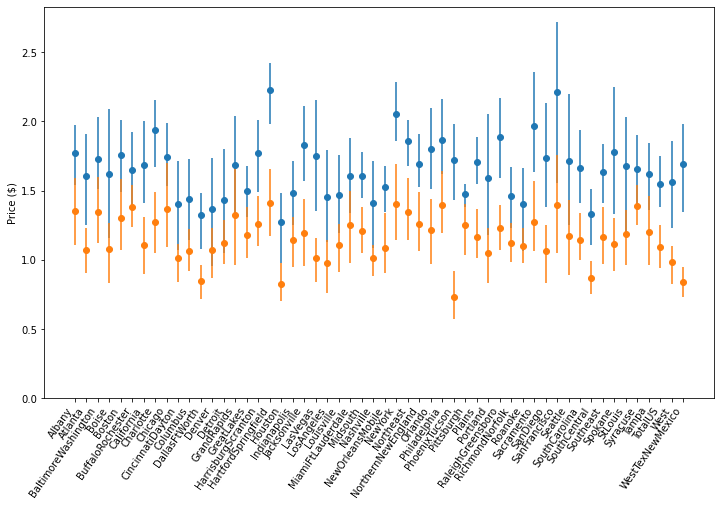

```python
fig,ax = plt.subplots(figsize=(12,8))
fig.autofmt_xdate(rotation=55 )
ax.errorbar(x = err_pdata.index,y=err_pdata['mean']['organic'],yerr=[err_pdata['q15']['organic'],err_pdata['q85']['organic']],fmt ='o')
ax.errorbar(x = err_pdata.index,y=err_pdata['mean']['conventional'],yerr=[err_pdata['q15']['conventional'],err_pdata['q85']['conventional']],fmt ='o')
ax.set_yticks([0,0.5,1,1.5,2,2.5])
ax.set_ylabel('Price ($)')
plt.show()
```

```
[]
```

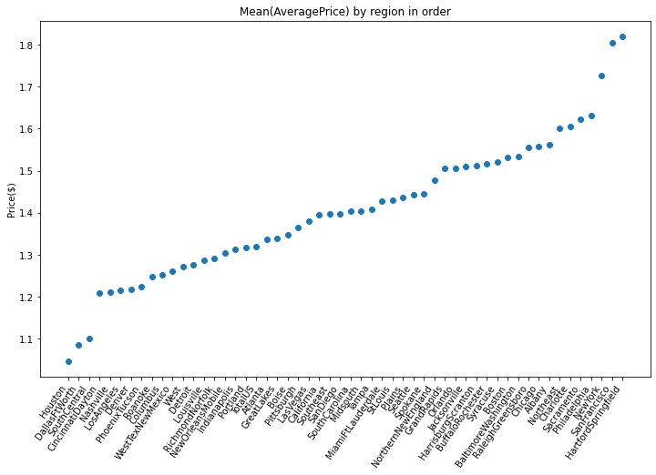

```python
price_by_region = data.groupby('region')['AveragePrice'].agg(['mean'])
price_by_region = price_by_region.sort_values('mean')
price_by_region = price_by_region.reset_index()
fig,ax = plt.subplots(figsize = (12,8))
fig.autofmt_xdate(rotation=55 )
ax.scatter(x=price_by_region['region'],y=price_by_region['mean'])
ax.set_title('Mean(AveragePrice) by region in order')
ax.set_ylabel('Price($)')
plt.plot()
```

Even though i think i will be a terrible fit, i want to fit a linear reggresion line to Price over year.

```python
houston = data[data['region']=='Houston']
h_organic = houston[houston['type']=='organic']
h_conv = houston[houston['type']=='conventional']
```

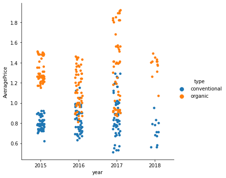

```python
fig = plt.figure(figsize=(5,4))
sns.catplot(data = houston,x='year',y='AveragePrice',hue='type')
plt.show()
```

```python
sample_means= (data.groupby(['year','type'])['AveragePrice'].mean())
sample_means = sample_means.unstack()

sample_n = data.groupby(['year','type'])['AveragePrice'].count()
sample_n
```

```
year  type
2015  conventional    2808
      organic         2807
2016  conventional    2808
      organic         2808
2017  conventional    2862
      organic         2860
2018  conventional     648
      organic          648
Name: AveragePrice, dtype: int64
```

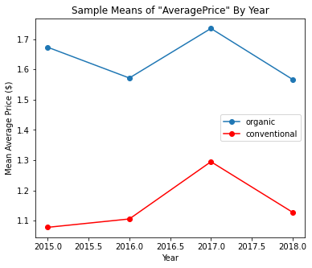

```python
fig = plt.figure(figsize=(6,5))
sample_means['organic'].plot(marker='o',label='organic')
sample_means['conventional'].plot(color='r',marker='o',label='conventional')
plt.title('Sample Means of "AveragePrice" By Year')
plt.ylabel('Mean Average Price ($)')
plt.xlabel('Year')
plt.legend()
plt.show()
```

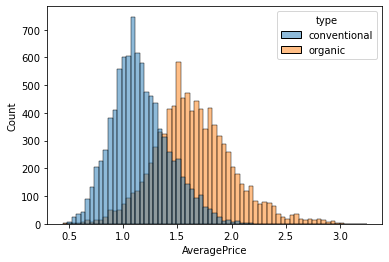

```python
sns.histplot(data,x='AveragePrice',hue='type')
```

### Organic

```python
slope_org, intercept_org, r_org, p_org, se_org = linregress(h_organic['year'],h_organic['AveragePrice'])
```

```
[]
```

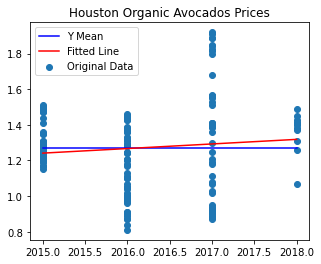

```python
fig = plt.figure(figsize=(5,4))
plt.scatter(h_organic['year'],h_organic['AveragePrice'],label='Original Data')
plt.plot(h_organic['year'],h_organic['year'].apply(lambda val :h_organic['AveragePrice'].mean()),label = 'Y Mean',c='b')
plt.plot(h_organic['year'],h_organic['year'].apply(lambda val : val*slope_org + intercept_org),label='Fitted Line',c='r')
plt.title('Houston Organic Avocados Prices')
plt.legend()
plt.plot()
```

#### coefficient of determination

```python
h_organic = h_organic.copy()
h_organic.loc[:,'y'] = h_organic.loc[:,'AveragePrice']
h_organic.loc[:,'mx+b'] = h_organic.loc[:,'year'].apply(lambda val : val*slope_org + intercept_org)
h_organic.loc[:,'SE_line']  = (h_organic.loc[:,'y'] - h_organic.loc[:,'mx+b'])**2
```

```python
one_minusr2 = round((1- h_organic.loc[:,'SE_line'].sum()/((h_organic.loc[:,'y']-h_organic.loc[:,'y'].mean())**2).sum()),2)
print(one_minusr2*100,'% of the total variation is described by the regression line y=',round(slope_org,2),'x',round(intercept_org,2))
```

```
1.0 % of the total variation is described by the regression line y= 0.03 x -50.59
```

### Conventional

```python
slope_con, intercept_con, r, p, se = linregress(h_conv['year'],h_conv['AveragePrice'])
```

```
[]
```

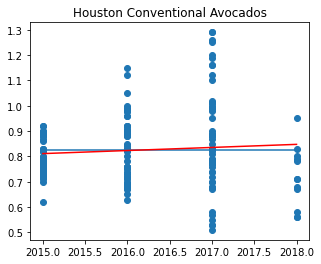

```python
fig = plt.figure(figsize=(5,4))
plt.scatter(h_conv['year'],h_conv['AveragePrice'])
plt.plot(h_conv['year'],h_conv['year'].apply(lambda val :h_conv['AveragePrice'].mean()))
plt.plot(h_conv['year'],h_conv['year'].apply(lambda val : val*slope_con + intercept_con),c='r')
plt.title('Houston Conventional Avocados')
plt.plot()
```

#### coefficient of determination

```python
h_conv = h_conv.copy()
h_conv.loc[:,'y'] = h_conv.loc[:,'AveragePrice']
h_conv.loc[:,'mx+b'] = h_conv.loc[:,'year'].apply(lambda val : val*slope_con + intercept_con)
h_conv.loc[:,'SE_line']  = (h_conv.loc[:,'y'] - h_conv.loc[:,'mx+b'])**2
```

```python
one_minusr2_con = round((1- h_conv.loc[:,'SE_line'].sum()/((h_conv.loc[:,'y']-h_conv.loc[:,'y'].mean())**2).sum()),2)
print(one_minusr2_con*100,'% of the total variation is described by the regression line y=',round(slope_con,2),'x',round(intercept_con,2))
```

```
1.0 % of the total variation is described by the regression line y= 0.01 x -23.65
```

- Not surprisingly simple linear regression, least squared line has not produced a reliable predictor, non the the less i wanted to put it into practive and visualize it.

```python
#noramlizing
from sklearn import preprocessing
from sklearn.decomposition import PCA
from sklearn.linear_model import LinearRegression
```

```python
def standardize(column,int_= False):
    if int_ ==True:
        values = normalized[column].sort_values().unique()
    else:
        values = normalized[column].unique()

    for i,v in enumerate(values):
        normalized.loc[normalized[column]==v, column]=i
```

```python
normalized = data.copy()
```

```python
#type- binary
normalized.loc[normalized['type'] == 'conventional','type']=0
normalized.loc[normalized['type'] == 'organic','type']=1

#region -nominal
standardize('region')

#year - ordinal
standardize('year',True)

#Date - ordinal
standardize('Date',True)
```

```python
normalized.head()
```

|  | Date | AveragePrice | Total Volume | 4046 | 4225 | 4770 | Total Bags | Small Bags | Large Bags | XLarge Bags | type | year | region |
| --- | --- | --- | --- | --- | --- | --- | --- | --- | --- | --- | --- | --- | --- |
| 0 | 51 | 1.33 | 64236.62 | 1036.74 | 54454.85 | 48.16 | 8696.87 | 8603.62 | 93.25 | 0.0 | 0 | 0 | 0 |
| 1 | 50 | 1.35 | 54876.98 | 674.28 | 44638.81 | 58.33 | 9505.56 | 9408.07 | 97.49 | 0.0 | 0 | 0 | 0 |
| 2 | 49 | 0.93 | 118220.22 | 794.70 | 109149.67 | 130.50 | 8145.35 | 8042.21 | 103.14 | 0.0 | 0 | 0 | 0 |
| 3 | 48 | 1.08 | 78992.15 | 1132.00 | 71976.41 | 72.58 | 5811.16 | 5677.40 | 133.76 | 0.0 | 0 | 0 | 0 |
| 4 | 47 | 1.28 | 51039.60 | 941.48 | 43838.39 | 75.78 | 6183.95 | 5986.26 | 197.69 | 0.0 | 0 | 0 | 0 |

```python
#dir(preprocessing)
```

```python
scaler = preprocessing.MinMaxScaler(feature_range = (-1,1))
names = normalized.columns

d = scaler.fit_transform(normalized)

stand_data=pd.DataFrame(data=d, columns=names)
stand_data.head()
```

|  | Date | AveragePrice | Total Volume | 4046 | 4225 | 4770 | Total Bags | Small Bags | Large Bags | XLarge Bags | type | year | region |
| --- | --- | --- | --- | --- | --- | --- | --- | --- | --- | --- | --- | --- | --- |
| 0 | -0.392857 | -0.366548 | -0.997947 | -0.999909 | -0.994680 | -0.999962 | -0.999102 | -0.998714 | -0.999967 | -1.0 | -1.0 | -1.0 | -1.0 |
| 1 | -0.404762 | -0.352313 | -0.998247 | -0.999941 | -0.995639 | -0.999954 | -0.999019 | -0.998594 | -0.999966 | -1.0 | -1.0 | -1.0 | -1.0 |
| 2 | -0.416667 | -0.651246 | -0.996220 | -0.999930 | -0.989336 | -0.999898 | -0.999159 | -0.998798 | -0.999964 | -1.0 | -1.0 | -1.0 | -1.0 |
| 3 | -0.428571 | -0.544484 | -0.997475 | -0.999900 | -0.992968 | -0.999943 | -0.999400 | -0.999152 | -0.999953 | -1.0 | -1.0 | -1.0 | -1.0 |
| 4 | -0.440476 | -0.402135 | -0.998370 | -0.999917 | -0.995717 | -0.999940 | -0.999362 | -0.999105 | -0.999931 | -1.0 | -1.0 | -1.0 | -1.0 |

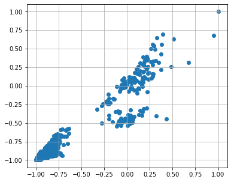

```python
plt.figure(figsize=(6,5))
plt.scatter(stand_data['Total Volume'],stand_data['Total Bags'])
plt.grid()
```

```python
correlations = stand_data.corr()
correlations[(correlations>0.5) | (correlations <-0.5)]
```

|  | Date | AveragePrice | Total Volume | 4046 | 4225 | 4770 | Total Bags | Small Bags | Large Bags | XLarge Bags | type | year | region |
| --- | --- | --- | --- | --- | --- | --- | --- | --- | --- | --- | --- | --- | --- |
| Date | 1.000000 | NaN | NaN | NaN | NaN | NaN | NaN | NaN | NaN | NaN | NaN | 0.950274 | NaN |
| AveragePrice | NaN | 1.000000 | NaN | NaN | NaN | NaN | NaN | NaN | NaN | NaN | 0.615845 | NaN | NaN |
| Total Volume | NaN | NaN | 1.000000 | 0.977863 | 0.974181 | 0.872202 | 0.963047 | 0.967238 | 0.880640 | 0.747157 | NaN | NaN | NaN |
| 4046 | NaN | NaN | 0.977863 | 1.000000 | 0.926110 | 0.833389 | 0.920057 | 0.925280 | 0.838645 | 0.699377 | NaN | NaN | NaN |
| 4225 | NaN | NaN | 0.974181 | 0.926110 | 1.000000 | 0.887855 | 0.905787 | 0.916031 | 0.810015 | 0.688809 | NaN | NaN | NaN |
| 4770 | NaN | NaN | 0.872202 | 0.833389 | 0.887855 | 1.000000 | 0.792314 | 0.802733 | 0.698471 | 0.679861 | NaN | NaN | NaN |
| Total Bags | NaN | NaN | 0.963047 | 0.920057 | 0.905787 | 0.792314 | 1.000000 | 0.994335 | 0.943009 | 0.804233 | NaN | NaN | NaN |
| Small Bags | NaN | NaN | 0.967238 | 0.925280 | 0.916031 | 0.802733 | 0.994335 | 1.000000 | 0.902589 | 0.806845 | NaN | NaN | NaN |
| Large Bags | NaN | NaN | 0.880640 | 0.838645 | 0.810015 | 0.698471 | 0.943009 | 0.902589 | 1.000000 | 0.710858 | NaN | NaN | NaN |
| XLarge Bags | NaN | NaN | 0.747157 | 0.699377 | 0.688809 | 0.679861 | 0.804233 | 0.806845 | 0.710858 | 1.000000 | NaN | NaN | NaN |
| type | NaN | 0.615845 | NaN | NaN | NaN | NaN | NaN | NaN | NaN | NaN | 1.000000 | NaN | NaN |
| year | 0.950274 | NaN | NaN | NaN | NaN | NaN | NaN | NaN | NaN | NaN | NaN | 1.000000 | NaN |
| region | NaN | NaN | NaN | NaN | NaN | NaN | NaN | NaN | NaN | NaN | NaN | NaN | 1.0 |

## PCA

which attributes account for the least varation on our data, those will be the least nessicary

```python
pca = PCA(n_components=stand_data.shape[1])

pca_fitted = pca.fit(stand_data)
components = pca.transform(stand_data)
```

```
[]
```

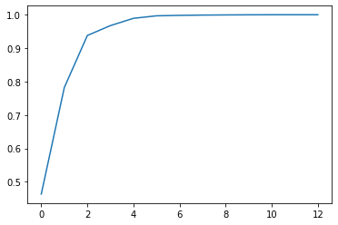

```python
#this is our ratio of variance explained by attributes.
var = pca_fitted.explained_variance_ratio_

#now we can visually see the redundant attributes
plt.plot(np.cumsum(var))
plt.plot()
```

```python
pca_c = ['pca_'+ str(i) for i in range(0,components.shape[1])]
pca_data = pd.DataFrame(components,columns=pca_c)
pca_data = pca_data.iloc[:,:3]
PCA_combined = stand_data.join(pca_data)
```

```python
PCA_combined.head()
```

|  | Date | AveragePrice | Total Volume | 4046 | 4225 | 4770 | Total Bags | Small Bags | Large Bags | XLarge Bags | type | year | region | pca_0 | pca_1 | pca_2 |
| --- | --- | --- | --- | --- | --- | --- | --- | --- | --- | --- | --- | --- | --- | --- | --- | --- |
| 0 | -0.392857 | -0.366548 | -0.997947 | -0.999909 | -0.994680 | -0.999962 | -0.999102 | -0.998714 | -0.999967 | -1.0 | -1.0 | -1.0 | -1.0 | 0.995166 | -0.809407 | -1.010630 |
| 1 | -0.404762 | -0.352313 | -0.998247 | -0.999941 | -0.995639 | -0.999954 | -0.999019 | -0.998594 | -0.999966 | -1.0 | -1.0 | -1.0 | -1.0 | 0.992663 | -0.816917 | -1.010737 |
| 2 | -0.416667 | -0.651246 | -0.996220 | -0.999930 | -0.989336 | -0.999898 | -0.999159 | -0.998798 | -0.999964 | -1.0 | -1.0 | -1.0 | -1.0 | 1.047656 | -0.836696 | -1.008749 |
| 3 | -0.428571 | -0.544484 | -0.997475 | -0.999900 | -0.992968 | -0.999943 | -0.999400 | -0.999152 | -0.999953 | -1.0 | -1.0 | -1.0 | -1.0 | 1.028121 | -0.840589 | -1.009538 |
| 4 | -0.440476 | -0.402135 | -0.998370 | -0.999917 | -0.995717 | -0.999940 | -0.999362 | -0.999105 | -0.999931 | -1.0 | -1.0 | -1.0 | -1.0 | 1.002134 | -0.843083 | -1.010455 |

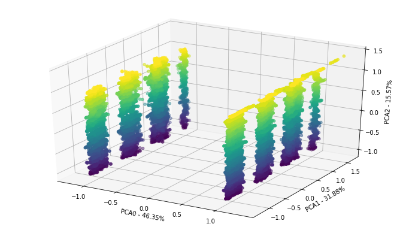

```python
plt.figure(figsize=(12,7))

ax = plt.axes(projection='3d')
xdata = PCA_combined.pca_0
ydata = PCA_combined.pca_1
zdata = PCA_combined.pca_2
ax.set_xlabel('PCA0 - {0}%'.format(round(var[0]*100,2)))
ax.set_ylabel('PCA1 - {0}%'.format(round(var[1]*100,2)))
ax.set_zlabel('PCA2 - {0}%'.format(round(var[2]*100,2)))
ax.scatter3D(xdata,ydata,zdata,c=PCA_combined.region)
plt.show()
```

```python
#data.to_csv('clean_data.csv')
```